# Initial Exploration of the RISX Index Data

Author

Mick Cooney mickcooney@gmail.com

Published

March 13, 2023

In this workbook we perform some basic investigation of the RISX index, that tracks the performance of the overall Lloyd’s Market via some financial engineering.

# 1 Load Data

## 1.1 Load and Inspect RISX Data

Daily values for the RISX index has been provided and is stored in the datafile with the name `RISX_index_data.xlsx`.

We load that data and then plot it.

```r
#! echo: true

risx_input_data_tbl <- read_excel("data/RISX_index_data.xlsx") |>
  set_colnames(c("date_dttm", "index_type", "index_name", "index_value")) |>
  mutate(
    date = date_dttm |> as.Date(),

    .before = 1
    )

risx_input_data_tbl |> glimpse()
```

```
Rows: 8,698
Columns: 5
$ date        <date> 2006-06-16, 2006-06-19, 2006-06-20, 2006-06-21, 2006-06-2…
$ date_dttm   <dttm> 2006-06-16, 2006-06-19, 2006-06-20, 2006-06-21, 2006-06-2…
$ index_type  <chr> "Price Return (RISX)", "Price Return (RISX)", "Price Retur…
$ index_name  <chr> "RISX", "RISX", "RISX", "RISX", "RISX", "RISX", "RISX", "R…
$ index_value <dbl> 1000.0000, 998.0101, 996.3504, 998.9300, 994.7633, 984.325…
```

## 1.2 Load and Inspect KIE ETF Data

We now repeat this process using the price data from the KIE ETF, which tracks the S&P Insurance industry group (a subset of the S&P 500).

This should prove as an interesting comparison point against the RISX values.

```r
min_data_date <- risx_input_data_tbl |> pull(date) |> min()
max_data_date <- risx_input_data_tbl |> pull(date) |> max()

kie_data_tbl <- tq_get("KIE", from = min_data_date, to = max_data_date) |>
  select(index_name = symbol, date, index_value = adjusted)

kie_data_tbl |> glimpse()
```

```
Rows: 4,211
Columns: 3
$ index_name  <chr> "KIE", "KIE", "KIE", "KIE", "KIE", "KIE", "KIE", "KIE", "K…
$ date        <date> 2006-06-16, 2006-06-19, 2006-06-20, 2006-06-21, 2006-06-2…
$ index_value <dbl> 12.50630, 12.45698, 12.45205, 12.47424, 12.41260, 12.38055…
```

## 1.3 Combine Index Data

To make it easier to run this analysis, we now combine all the data into a single table with daily values for each ticker symbol.

```r
index_data_tbl <- list(
      risx_input_data_tbl |> select(index_name, date, index_value),
      kie_data_tbl
    ) |>
  bind_rows()

index_data_tbl |> glimpse()
```

```
Rows: 12,909
Columns: 3
$ index_name  <chr> "RISX", "RISX", "RISX", "RISX", "RISX", "RISX", "RISX", "R…
$ date        <date> 2006-06-16, 2006-06-19, 2006-06-20, 2006-06-21, 2006-06-2…
$ index_value <dbl> 1000.0000, 998.0101, 996.3504, 998.9300, 994.7633, 984.325…
```

## 1.4 Lineplot of the Index Values

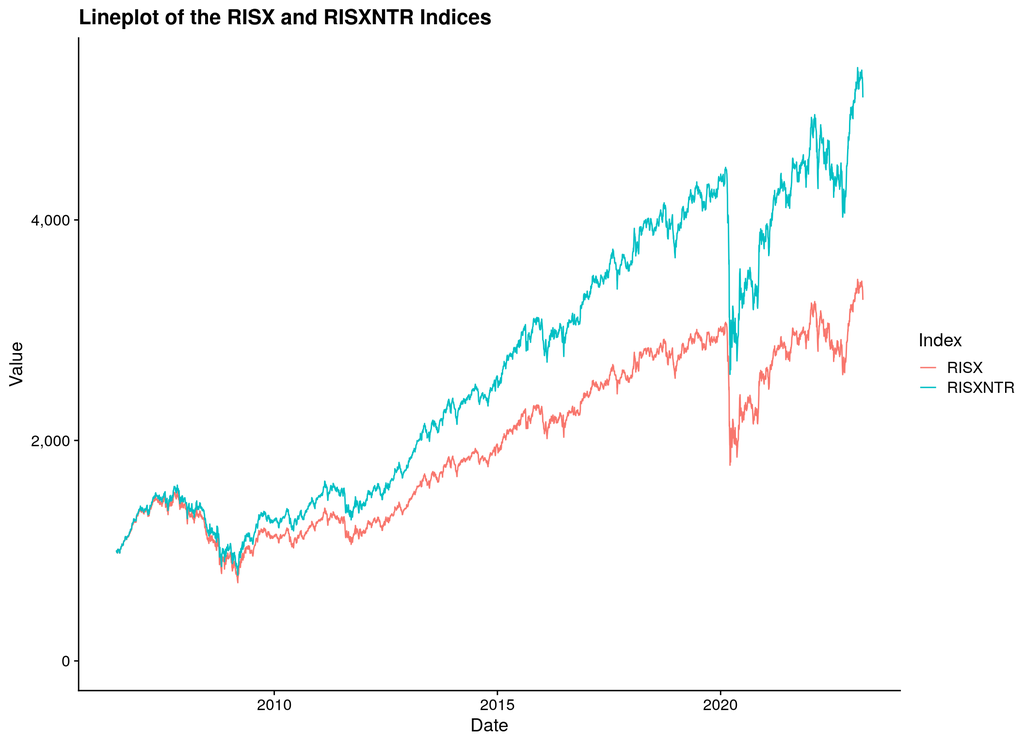

```r
#! echo: true
plot_data_tbl <- index_data_tbl |>
  filter(index_name %in% c("RISX", "RISXNTR"))


ggplot(plot_data_tbl) +
  geom_line(aes(x = date, y = index_value, colour = index_name)) +
  expand_limits(y = 0) +
  scale_y_continuous(labels = label_comma()) +
  labs(
    x = "Date",
    y = "Value",
    colour = "Index",
    title = "Lineplot of the RISX and RISXNTR Indices"
    )
```

We also want to calculate the daily returns of the index and we can use that using features in the `tidyquant` package.

```r
index_daily_returns_tbl <- index_data_tbl |>
  group_by(index_name) |>
  tq_transmute(
    index_value, dailyReturn, col_rename = "daily_return"
    ) |>
  ungroup()

index_daily_returns_tbl |> glimpse()
```

```
Rows: 12,909
Columns: 3
$ index_name   <chr> "RISX", "RISX", "RISX", "RISX", "RISX", "RISX", "RISX", "…
$ date         <date> 2006-06-16, 2006-06-19, 2006-06-20, 2006-06-21, 2006-06-…
$ daily_return <dbl> 0.000000e+00, -1.989900e-03, -1.663009e-03, 2.589049e-03,…
```

We also want to calculate monthly returns, as the distribution of them is closer to a Normal distribution than daily returns.

```r
index_monthly_returns_tbl <- index_data_tbl |>
  group_by(index_name) |>
  tq_transmute(
    index_value, monthlyReturn, col_rename = "monthly_return"
    ) |>
  ungroup()

index_monthly_returns_tbl |> glimpse()
```

```
Rows: 606
Columns: 3
$ index_name     <chr> "RISX", "RISX", "RISX", "RISX", "RISX", "RISX", "RISX",…
$ date           <date> 2006-06-30, 2006-07-31, 2006-08-31, 2006-09-29, 2006-1…
$ monthly_return <dbl> 0.010065300, 0.028369354, 0.078207875, 0.012445753, 0.0…
```

# 2 Investigate Index Returns

For now we focus our initial investigations into the basic price index, RISX. Later we can repeat the analysis for the RISXNTR as this will capture the full effect of being invested in these business. We expect the effect of dividends to be significant as insurance companies typically provide solid dividends as a matter of course.

## 2.1 RISX Index

For the moment though, we focus on the RISX.

```r
risx_daily_returns_tbl <- index_daily_returns_tbl |>
  filter(index_name == "RISX")

risx_daily_returns_tbl |> glimpse()
```

```
Rows: 4,349
Columns: 3
$ index_name   <chr> "RISX", "RISX", "RISX", "RISX", "RISX", "RISX", "RISX", "…
$ date         <date> 2006-06-16, 2006-06-19, 2006-06-20, 2006-06-21, 2006-06-…
$ daily_return <dbl> 0.000000e+00, -1.989900e-03, -1.663009e-03, 2.589049e-03,…
```

```r
risx_monthly_returns_tbl <- index_monthly_returns_tbl |>
  filter(index_name == "RISX")

risx_monthly_returns_tbl |> glimpse()
```

```
Rows: 202
Columns: 3
$ index_name     <chr> "RISX", "RISX", "RISX", "RISX", "RISX", "RISX", "RISX",…
$ date           <date> 2006-06-30, 2006-07-31, 2006-08-31, 2006-09-29, 2006-1…
$ monthly_return <dbl> 0.010065300, 0.028369354, 0.078207875, 0.012445753, 0.0…
```

We start by looking at the overall distribution of returns, and compare those to the corresponding Normal distribution (as determined by the sample mean and standard deviation of those returns).

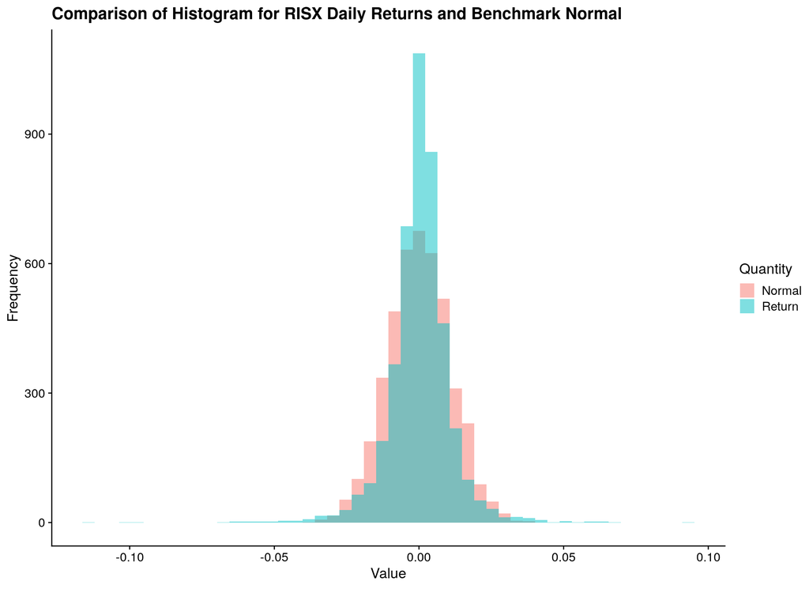

```r
#! echo: true

return_mu <- risx_daily_returns_tbl |> pull(daily_return) |> mean()
return_sd <- risx_daily_returns_tbl |> pull(daily_return) |> sd()

plot_tbl <- risx_daily_returns_tbl |>
  mutate(
    `Return` = daily_return,
    `Normal` = rnorm(n(), mean = return_mu, sd = return_sd)
    ) |>
  pivot_longer(
    cols      = c(Return, Normal),
    names_to  = "label",
    values_to = "value"
    )

ggplot(plot_tbl) +
  geom_histogram(
    aes(x = value, fill = label),
    position = "identity", bins = 50, alpha = 0.5
    ) +
  scale_y_continuous(labels = label_comma()) +
  labs(
    x     = "Value",
    y     = "Frequency",
    fill  = "Quantity",
    title = "Comparison of Histogram for RISX Daily Returns and Benchmark Normal"
    )
```

We now repeat this exercise with the monthly returns.

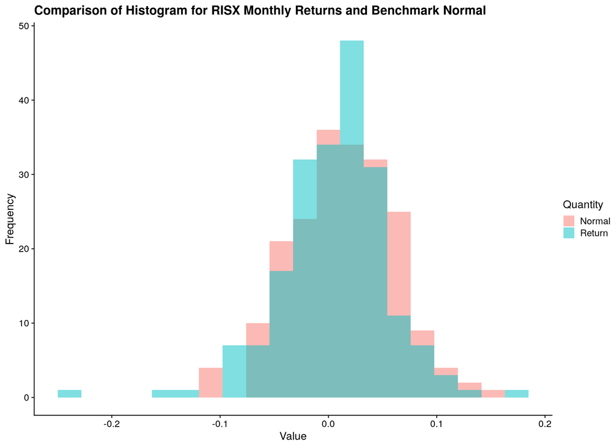

```r
#! echo: true

return_mu <- risx_monthly_returns_tbl |> pull(monthly_return) |> mean()
return_sd <- risx_monthly_returns_tbl |> pull(monthly_return) |> sd()

plot_tbl <- risx_monthly_returns_tbl |>
  mutate(
    `Return` = monthly_return,
    `Normal` = rnorm(n(), mean = return_mu, sd = return_sd)
    ) |>
  pivot_longer(
    cols      = c(Return, Normal),
    names_to  = "label",
    values_to = "value"
    )

ggplot(plot_tbl) +
  geom_histogram(
    aes(x = value, fill = label),
    position = "identity", bins = 20, alpha = 0.5
    ) +
  scale_y_continuous(labels = label_comma()) +
  labs(
    x     = "Value",
    y     = "Frequency",
    fill  = "Quantity",
    title = "Comparison of Histogram for RISX Monthly Returns and Benchmark Normal"
    )
```